# Chronic infections reduce mortality following unrelated secondary infections in Drosophila melanogaster

Abigail Wukitch

11/10/2021

## Ready the workspace

Load all necessary libraries, packages, and data files

```r
library(survival)
library(RColorBrewer)
library(ggplot2)
library(rlang)
library(agricolae)

rm(list=ls()) #removes all old variables
E.fae_P.rett = read.csv("E.fae-P.rett.csv")
E.fae_bacterial_load = read.csv("E.fae bacterial load data.csv")
S.m_P.rett_no_extremes = read.csv("S.m-P.rett no extremes.csv")
S.m_bacterial_load = read.csv("S.m bacterial load data.csv")
S.m_P.rett_extremes = read.csv("S.m-P.rett extremes.csv")
S.m_P.snee = read.csv("S.m-P.snee.csv")
P.rett_varied_primary = read.csv("Varied primary S.m-P.rett.csv")
P.snee_varied_primary = read.csv("Varied primary S.m-P.snee.csv")

#S.m_P.rett_no_extremes 7/10/18 is the problematic one - need to delete
#S.m_P.rett_no8 <- subset(S.m_P.rett_no_extremes, date == "6/14/2019" | date == "6/17/2019" | date == "6/19/2019" | date == "6/25/2019" | date == "6/27/2019" | date == "6/28/2019" | date == "8/2/2018" | date == "8/6/2018")
#table(S.m_P.rett_no8$date, S.m_P.rett_no8$secondary_dose)

#write.csv(S.m_P.rett_no8, "S.m_P.rett no extremes.csv")
```

## Figure 1A

Chronic infections with S. marcescens provided protection against mortality following secondary infection with P. rettgeri

### Graph

Mortality following secondary infection with P. rettgeri in flies chronically infected with S. marcescens versus control flies not given a chronic infection. Flies chronically infected with S. marcescens were more likely to survive various doses of secondary infection with P. rettgeri (p < 0.0001).

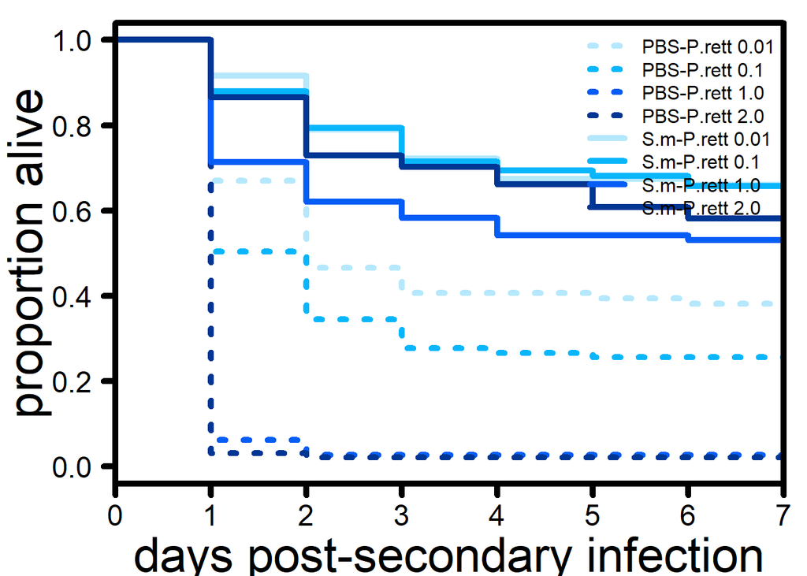

```r
S.m_P.rett_no_extremes$primary <- ordered(S.m_P.rett_no_extremes$primary, levels = c("PBS", "S.m"))
#table(S.m_P.rett_no_extremes$primary, S.m_P.rett_no_extremes$secondary_dose)

S.m_bacterial_load$primary <- ordered(S.m_bacterial_load$primary, levels = c("PBS", "S.m"))
#table(S.m_bacterial_load$primary, S.m_bacterial_load$secondary_dose)

#THE GRAPH
#png(file="S.m_P.rett_no_extremes.png",width=1200,height=900,res=130)
par(mar=c(4,5,1,1)) #sets the margins around the graph so there is room for the labels
plot(survfit(Surv(S.m_P.rett_no_extremes$day, S.m_P.rett_no_extremes$status) ~ S.m_P.rett_no_extremes$primary + S.m_P.rett_no_extremes$secondary_dose), col=c("#B5E8FC",  "#09B6FC", "#055df5", "#003694"), lty=c(3, 3, 3, 3, 1, 1, 1, 1), lwd=5,yaxt='n', xaxt='n', ylab="proportion alive", xlab="days post-secondary infection", cex.lab=2.5, xlim=c(0,7), xaxs='i')
axis(2, las=2, cex.axis=1.5, lwd=5)
axis(1, cex.axis=1.5, lwd=5)
box(lwd=5)

#THE LEGEND
legend("topright",inset=0, bty="n" , c("PBS-P.rett 0.01", "PBS-P.rett 0.1", "PBS-P.rett 1.0", "PBS-P.rett 2.0", "S.m-P.rett 0.01", "S.m-P.rett 0.1", "S.m-P.rett 1.0", "S.m-P.rett 2.0"),col=c("#B5E8FC", "#09B6FC", "#055df5", "#003694"),lty=c(3, 3, 3, 3, 1, 1, 1, 1),lwd=5, cex=1)
```

### Statistics

```r
#STATISTICS
S.m_P.rett_no_extremes$secondary_dose <- as.factor(S.m_P.rett_no_extremes$secondary_dose)
S.m_P.rett_no_extremes_coxph <- coxph(Surv(day, status) ~ secondary_dose + primary + rep + primary:secondary_dose + rep:secondary_dose + rep:primary, data = S.m_P.rett_no_extremes)
#summary(S.m_P.rett_no_extremes_coxph)
anova(S.m_P.rett_no_extremes_coxph)
```

```
## Analysis of Deviance Table
##  Cox model: response is Surv(day, status)
## Terms added sequentially (first to last)
##
##                         loglik   Chisq Df Pr(>|Chi|)
## NULL                   -3352.5
## secondary_dose         -3318.7  67.561  3  1.421e-14 ***
## primary                -3174.9 287.582  1  < 2.2e-16 ***
## rep                    -3158.8  32.210  6  1.487e-05 ***
## secondary_dose:primary -3144.1  29.332  3  1.907e-06 ***
## secondary_dose:rep     -3127.7  32.855 16   0.007724 **
## primary:rep            -3112.4  30.639  6  2.971e-05 ***
## ---
## Signif. codes:  0 '***' 0.001 '**' 0.01 '*' 0.05 '.' 0.1 ' ' 1
```

### Block 1

```r
S.m_P.rett_no_extremes_block1 <- subset(S.m_P.rett_no_extremes, date == "8/2/2018")
table(S.m_P.rett_no_extremes_block1$primary, S.m_P.rett_no_extremes_block1$secondary_dose)
```

```
##
##       0.01 0.1  1  2
##   PBS   17  18 18  0
##   S.m   15  15 15  0
```

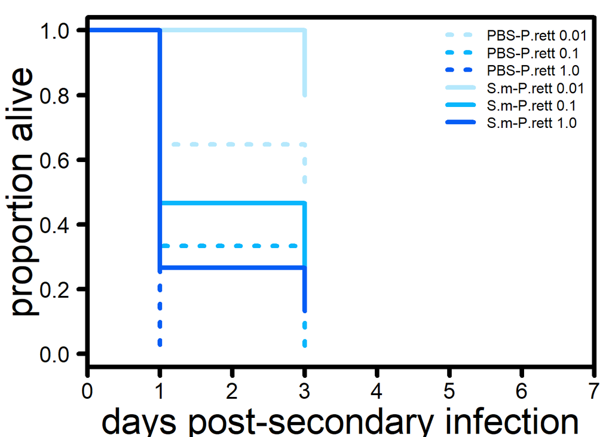

```r
#THE GRAPH
par(mar=c(4,5,1,1))
plot(survfit(Surv(S.m_P.rett_no_extremes_block1$day, S.m_P.rett_no_extremes_block1$status) ~ S.m_P.rett_no_extremes_block1$primary + S.m_P.rett_no_extremes_block1$secondary_dose), col=c("#B5E8FC",  "#09B6FC", "#055df5"), lty=c(3, 3, 3, 1, 1, 1), lwd=5,yaxt='n', xaxt='n', ylab="proportion alive", xlab="days post-secondary infection", cex.lab=2.5, xlim=c(0,7), xaxs='i')
axis(2, las=2, cex.axis=1.5, lwd=5)
axis(1, cex.axis=1.5, lwd=5)
box(lwd=5)

#THE LEGEND
legend("topright",inset=0, bty="n" , c("PBS-P.rett 0.01", "PBS-P.rett 0.1", "PBS-P.rett 1.0", "S.m-P.rett 0.01", "S.m-P.rett 0.1", "S.m-P.rett 1.0"),col=c("#B5E8FC", "#09B6FC", "#055df5"),lty=c(3, 3, 3, 1, 1, 1),lwd=5, cex=1)
```

### Block 2

```r
S.m_P.rett_no_extremes_block2 <- subset(S.m_P.rett_no_extremes, date == "8/6/2018")
table(S.m_P.rett_no_extremes_block2$primary, S.m_P.rett_no_extremes_block2$secondary_dose)
```

```
##
##       0.01 0.1  1  2
##   PBS   19  27 12  0
##   S.m   24  23 15  0
```

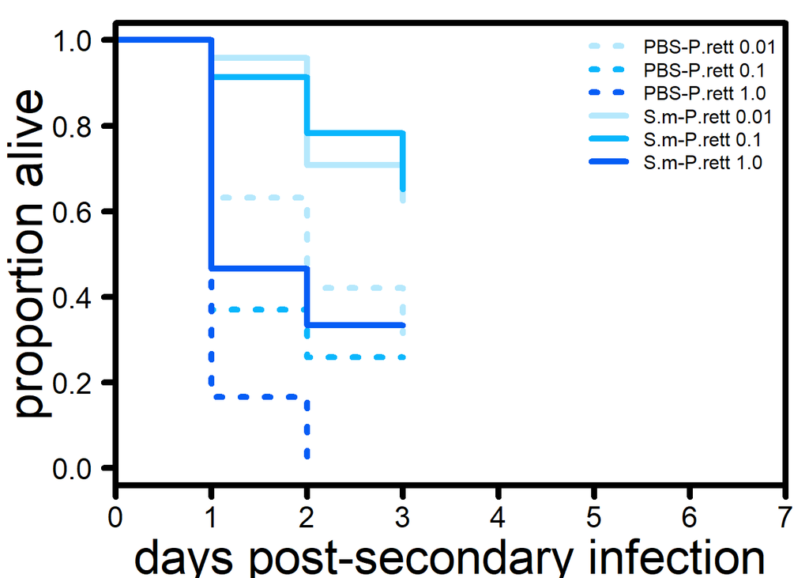

```r
#THE GRAPH
par(mar=c(4,5,1,1))
plot(survfit(Surv(S.m_P.rett_no_extremes_block2$day, S.m_P.rett_no_extremes_block2$status) ~ S.m_P.rett_no_extremes_block2$primary + S.m_P.rett_no_extremes_block2$secondary_dose), col=c("#B5E8FC",  "#09B6FC", "#055df5"), lty=c(3, 3, 3, 1, 1, 1), lwd=5,yaxt='n', xaxt='n', ylab="proportion alive", xlab="days post-secondary infection", cex.lab=2.5, xlim=c(0,7), xaxs='i')
axis(2, las=2, cex.axis=1.5, lwd=5)
axis(1, cex.axis=1.5, lwd=5)
box(lwd=5)

#THE LEGEND
legend("topright",inset=0, bty="n" , c("PBS-P.rett 0.01", "PBS-P.rett 0.1", "PBS-P.rett 1.0", "S.m-P.rett 0.01", "S.m-P.rett 0.1", "S.m-P.rett 1.0"),col=c("#B5E8FC", "#09B6FC", "#055df5"),lty=c(3, 3, 3, 1, 1, 1),lwd=5, cex=1)
```

### Block 3

```r
S.m_P.rett_no_extremes_block3 <- subset(S.m_P.rett_no_extremes, date == "6/14/2019")
table(S.m_P.rett_no_extremes_block3$primary, S.m_P.rett_no_extremes_block3$secondary_dose)
```

```
##
##       0.01 0.1  1  2
##   PBS   15  14 17 20
##   S.m   15  19 17 18
```

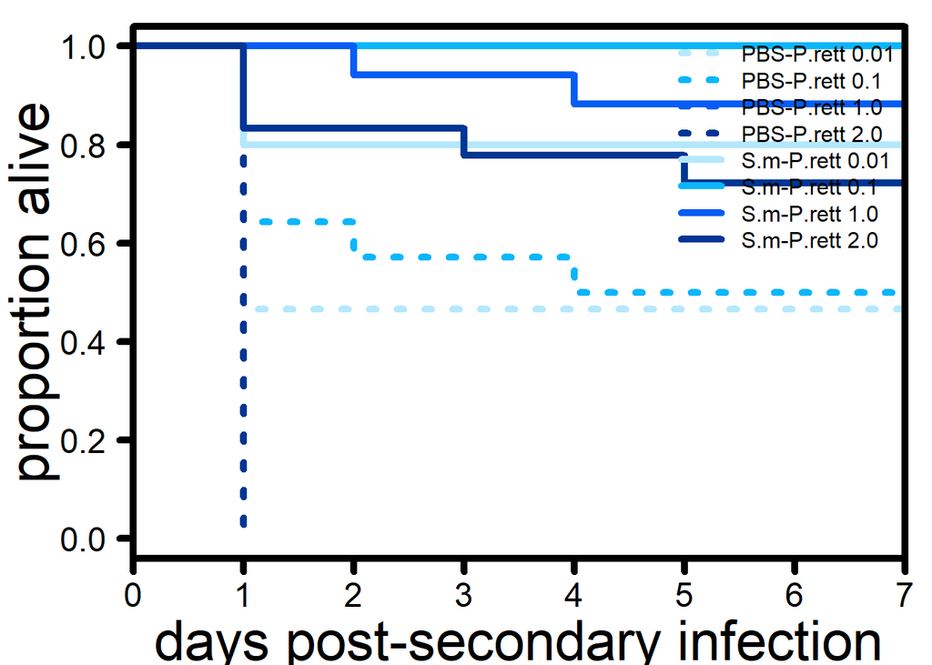

```r
#THE GRAPH
par(mar=c(4,5,1,1))
plot(survfit(Surv(S.m_P.rett_no_extremes_block3$day, S.m_P.rett_no_extremes_block3$status) ~ S.m_P.rett_no_extremes_block3$primary + S.m_P.rett_no_extremes_block3$secondary_dose), col=c("#B5E8FC",  "#09B6FC", "#055df5", "#003694"), lty=c(3, 3, 3, 3, 1, 1, 1, 1), lwd=5,yaxt='n', xaxt='n', ylab="proportion alive", xlab="days post-secondary infection", cex.lab=2.5, xlim=c(0,7), xaxs='i')
axis(2, las=2, cex.axis=1.5, lwd=5)
axis(1, cex.axis=1.5, lwd=5)
box(lwd=5)

#THE LEGEND
legend("topright",inset=0, bty="n" , c("PBS-P.rett 0.01", "PBS-P.rett 0.1", "PBS-P.rett 1.0", "PBS-P.rett 2.0", "S.m-P.rett 0.01", "S.m-P.rett 0.1", "S.m-P.rett 1.0", "S.m-P.rett 2.0"),col=c("#B5E8FC", "#09B6FC", "#055df5", "#003694"),lty=c(3, 3, 3, 3, 1, 1, 1, 1),lwd=5, cex=1)
```

### Block 4

```r
S.m_P.rett_no_extremes_block4 <- subset(S.m_P.rett_no_extremes, date == "6/17/2019")
table(S.m_P.rett_no_extremes_block4$primary, S.m_P.rett_no_extremes_block4$secondary_dose)
```

```
##
##       0.01 0.1  1  2
##   PBS   15  19 17 17
##   S.m   18  13 16 11
```

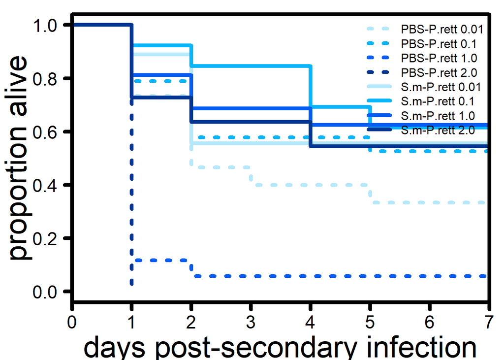

```r
#THE GRAPH
par(mar=c(4,5,1,1))
plot(survfit(Surv(S.m_P.rett_no_extremes_block4$day, S.m_P.rett_no_extremes_block4$status) ~ S.m_P.rett_no_extremes_block4$primary + S.m_P.rett_no_extremes_block4$secondary_dose), col=c("#B5E8FC",  "#09B6FC", "#055df5", "#003694"), lty=c(3, 3, 3, 3, 1, 1, 1, 1), lwd=5,yaxt='n', xaxt='n', ylab="proportion alive", xlab="days post-secondary infection", cex.lab=2.5, xlim=c(0,7), xaxs='i')
axis(2, las=2, cex.axis=1.5, lwd=5)
axis(1, cex.axis=1.5, lwd=5)
box(lwd=5)

#THE LEGEND
legend("topright",inset=0, bty="n" , c("PBS-P.rett 0.01", "PBS-P.rett 0.1", "PBS-P.rett 1.0", "PBS-P.rett 2.0", "S.m-P.rett 0.01", "S.m-P.rett 0.1", "S.m-P.rett 1.0", "S.m-P.rett 2.0"),col=c("#B5E8FC", "#09B6FC", "#055df5", "#003694"),lty=c(3, 3, 3, 3, 1, 1, 1, 1),lwd=5, cex=1)
```

### Block 5

```r
S.m_P.rett_no_extremes_block5 <- subset(S.m_P.rett_no_extremes, date == "6/19/2019")
table(S.m_P.rett_no_extremes_block5$primary, S.m_P.rett_no_extremes_block5$secondary_dose)
```

```
##
##       0.01 0.1  1  2
##   PBS   15   5  9 19
##   S.m   11  17 14 15
```

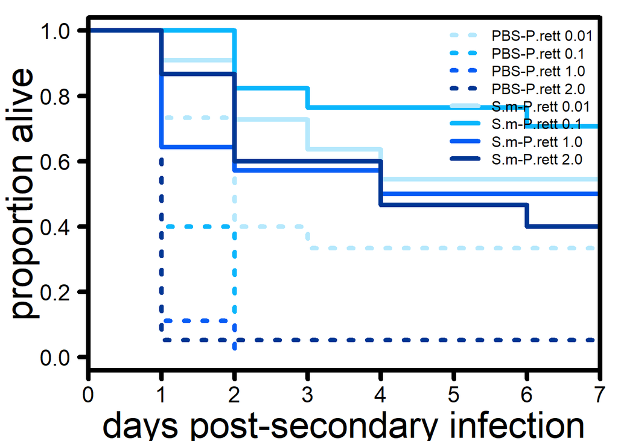

```r
#THE GRAPH
par(mar=c(4,5,1,1))
plot(survfit(Surv(S.m_P.rett_no_extremes_block5$day, S.m_P.rett_no_extremes_block5$status) ~ S.m_P.rett_no_extremes_block5$primary + S.m_P.rett_no_extremes_block5$secondary_dose), col=c("#B5E8FC",  "#09B6FC", "#055df5", "#003694"), lty=c(3, 3, 3, 3, 1, 1, 1, 1), lwd=5,yaxt='n', xaxt='n', ylab="proportion alive", xlab="days post-secondary infection", cex.lab=2.5, xlim=c(0,7), xaxs='i')
axis(2, las=2, cex.axis=1.5, lwd=5)
axis(1, cex.axis=1.5, lwd=5)
box(lwd=5)

#THE LEGEND
legend("topright",inset=0, bty="n" , c("PBS-P.rett 0.01", "PBS-P.rett 0.1", "PBS-P.rett 1.0", "PBS-P.rett 2.0", "S.m-P.rett 0.01", "S.m-P.rett 0.1", "S.m-P.rett 1.0", "S.m-P.rett 2.0"),col=c("#B5E8FC", "#09B6FC", "#055df5", "#003694"),lty=c(3, 3, 3, 3, 1, 1, 1, 1),lwd=5, cex=1)
```

### Block 6

```r
S.m_P.rett_no_extremes_block6 <- subset(S.m_P.rett_no_extremes, date == "6/25/2019")
table(S.m_P.rett_no_extremes_block6$primary, S.m_P.rett_no_extremes_block6$secondary_dose)
```

```
##
##       0.01 0.1  1  2
##   PBS   17  19 19 20
##   S.m   20  15 17 16
```

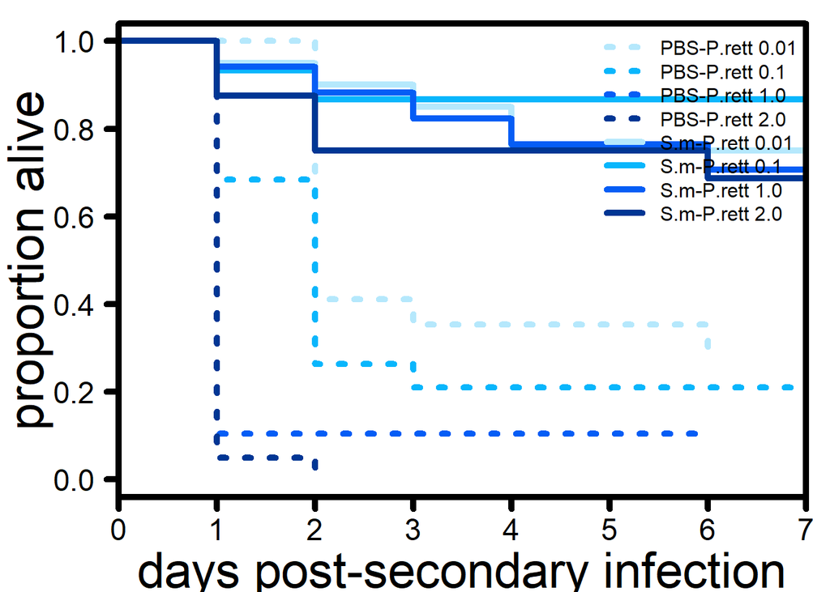

```r
#THE GRAPH
par(mar=c(4,5,1,1))
plot(survfit(Surv(S.m_P.rett_no_extremes_block6$day, S.m_P.rett_no_extremes_block6$status) ~ S.m_P.rett_no_extremes_block6$primary + S.m_P.rett_no_extremes_block6$secondary_dose), col=c("#B5E8FC",  "#09B6FC", "#055df5", "#003694"), lty=c(3, 3, 3, 3, 1, 1, 1, 1), lwd=5,yaxt='n', xaxt='n', ylab="proportion alive", xlab="days post-secondary infection", cex.lab=2.5, xlim=c(0,7), xaxs='i')
axis(2, las=2, cex.axis=1.5, lwd=5)
axis(1, cex.axis=1.5, lwd=5)
box(lwd=5)

#THE LEGEND
legend("topright",inset=0, bty="n" , c("PBS-P.rett 0.01", "PBS-P.rett 0.1", "PBS-P.rett 1.0", "PBS-P.rett 2.0", "S.m-P.rett 0.01", "S.m-P.rett 0.1", "S.m-P.rett 1.0", "S.m-P.rett 2.0"),col=c("#B5E8FC", "#09B6FC", "#055df5", "#003694"),lty=c(3, 3, 3, 3, 1, 1, 1, 1),lwd=5, cex=1)
```

### Block 7

```r
S.m_P.rett_no_extremes_block7 <- subset(S.m_P.rett_no_extremes, date == "6/27/2019")
table(S.m_P.rett_no_extremes_block7$primary, S.m_P.rett_no_extremes_block7$secondary_dose)
```

```
##
##       0.01 0.1  1  2
##   PBS   20  17 20 19
##   S.m   16  14 14 14
```

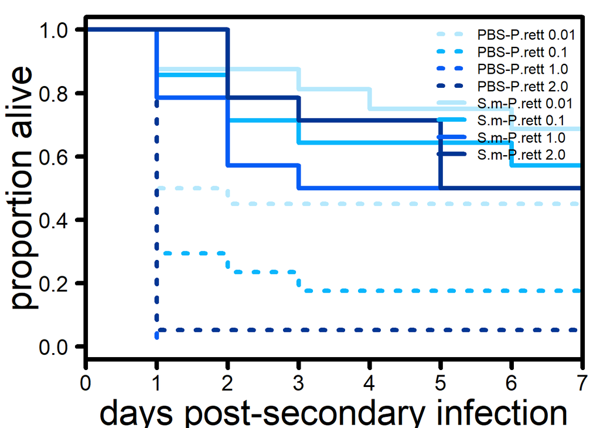

```r
#THE GRAPH
par(mar=c(4,5,1,1))
plot(survfit(Surv(S.m_P.rett_no_extremes_block7$day, S.m_P.rett_no_extremes_block7$status) ~ S.m_P.rett_no_extremes_block7$primary + S.m_P.rett_no_extremes_block7$secondary_dose), col=c("#B5E8FC",  "#09B6FC", "#055df5", "#003694"), lty=c(3, 3, 3, 3, 1, 1, 1, 1), lwd=5,yaxt='n', xaxt='n', ylab="proportion alive", xlab="days post-secondary infection", cex.lab=2.5, xlim=c(0,7), xaxs='i')
axis(2, las=2, cex.axis=1.5, lwd=5)
axis(1, cex.axis=1.5, lwd=5)
box(lwd=5)

#THE LEGEND
legend("topright",inset=0, bty="n" , c("PBS-P.rett 0.01", "PBS-P.rett 0.1", "PBS-P.rett 1.0", "PBS-P.rett 2.0", "S.m-P.rett 0.01", "S.m-P.rett 0.1", "S.m-P.rett 1.0", "S.m-P.rett 2.0"),col=c("#B5E8FC", "#09B6FC", "#055df5", "#003694"),lty=c(3, 3, 3, 3, 1, 1, 1, 1),lwd=5, cex=1)
```

## Figure 1B

Chronic infections with E. faecalis provided protection against mortality following secondary infection with P. rettgeri

### Graph

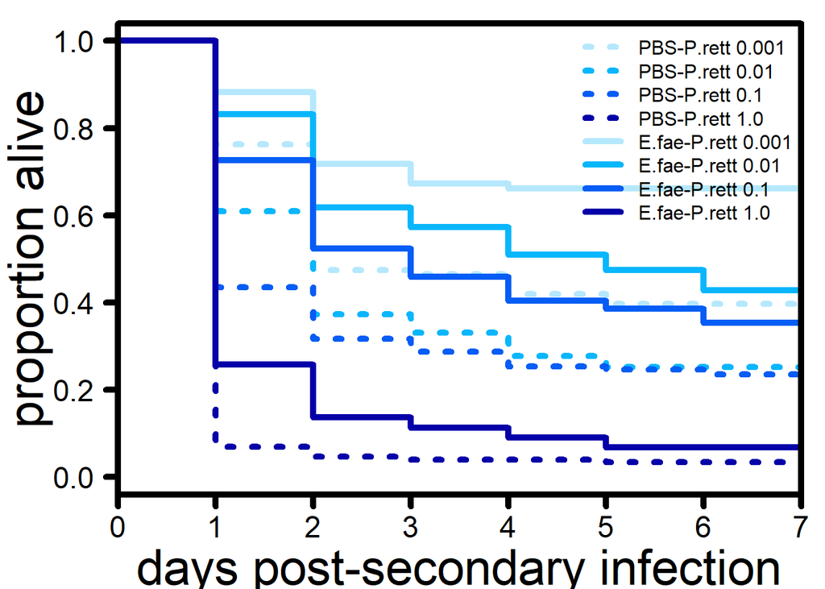

```r
E.fae_P.rett$primary <- ordered(E.fae_P.rett$primary, levels = c("PBS", "E.fae"))

E.fae_bacterial_load$primary <- ordered(E.fae_bacterial_load$primary, levels = c("PBS", "E.fae"))

#KAPLAN MEIER
#table(E.fae_P.rett$primary, E.fae_P.rett$secondary_dose) #tells you the number of flies in each condition
#png(file="E.fae-P.rett.png", width=1200, heigh=900, res=130) #determines where the graph will be saved
par(mar=c(4,5,1,1)) #sets the margins around the graph so there is room for the labels
#The graph
plot(survfit(Surv(E.fae_P.rett$day, E.fae_P.rett$status) ~ E.fae_P.rett$primary + E.fae_P.rett$secondary_dose),
     col=c("#B5E8FC", "#09B6FC", "#055df5", "#0600a8"), #line color, cycles through
     lty=c(3, 3, 3, 3, 1, 1, 1, 1), #line type
     lwd=5, #line width
     yaxt='n', #hide the y axis so I can customize it
     xaxt='n', #hide the x axis so I can customize itS
     ylab="proportion alive", #label for the y-axis
     xlab="days post-secondary infection", #label for the x-axis
     cex.lab=2.5, #font size of axis labels
     xlim=c(0,7), #determines range of the x-axis
     xaxs='i') #makes the data flush with the axis
#Y axis
axis(2, #left side
     las=2, #perpendicular to the axis
     cex.axis=1.5, #font size
     lwd=5) #line width
#X axis
axis(1, #bottom of the graph
     cex.axis=1.5, #font size
     lwd=5) #line width
box(lwd=5)
#The legend
legend("topright", #location
       bty="n", #no box around the legend
       c("PBS-P.rett 0.001", "PBS-P.rett 0.01", "PBS-P.rett 0.1", 'PBS-P.rett 1.0', "E.fae-P.rett 0.001", "E.fae-P.rett 0.01", "E.fae-P.rett 0.1", "E.fae-P.rett 1.0"), #labels in the legend
       col=c("#B5E8FC", "#09B6FC", "#055df5", "#0600a8"), #colors for the legend lines, cycles through
       lty=c(3, 3, 3, 3, 1, 1, 1, 1), #line type for legend lines
       lwd=5, #line width for legend lines
       cex=1) #font size
```

### Statistics

```r
#SURVIVAL STATISTICS
#Generate a Cox proportional Hazards model which assesses the contribution of infectious dose while controlling for replicate
E.fae_P.rett$secondary_dose <- as.factor(E.fae_P.rett$secondary_dose)
E.fae_P.rett_coxph <- coxph(Surv(day, status) ~ secondary_dose + primary + rep + primary:secondary_dose + rep:secondary_dose + rep:primary, data = E.fae_P.rett)
#summary(E.fae_P.rett_coxph)
anova(E.fae_P.rett_coxph)
```

```
## Analysis of Deviance Table
##  Cox model: response is Surv(day, status)
## Terms added sequentially (first to last)
##
##                         loglik    Chisq Df Pr(>|Chi|)
## NULL                   -5196.9
## secondary_dose         -5063.6 266.5666  3  < 2.2e-16 ***
## primary                -5037.0  53.1520  1  3.087e-13 ***
## rep                    -4995.0  83.9735  7  2.126e-15 ***
## secondary_dose:primary -4994.1   1.8985  3     0.5937
## secondary_dose:rep     -4982.9  22.4280 18     0.2135
## primary:rep            -4978.3   9.1867  7     0.2395
## ---
## Signif. codes:  0 '***' 0.001 '**' 0.01 '*' 0.05 '.' 0.1 ' ' 1
```

```r
table(E.fae_P.rett$rep, E.fae_P.rett$secondary_dose)
```

```
##
##        0.001 0.01 0.1  1
##   3       61   36  48 59
##   4       48   42  54 56
##   I       30   34  25 29
##   II      40   37  38 37
##   III      0   36  35 37
##   IV       0   37  41 37
##   IX/V    32   45  34 27
##   V        0   33  26 22
```

### Block 1

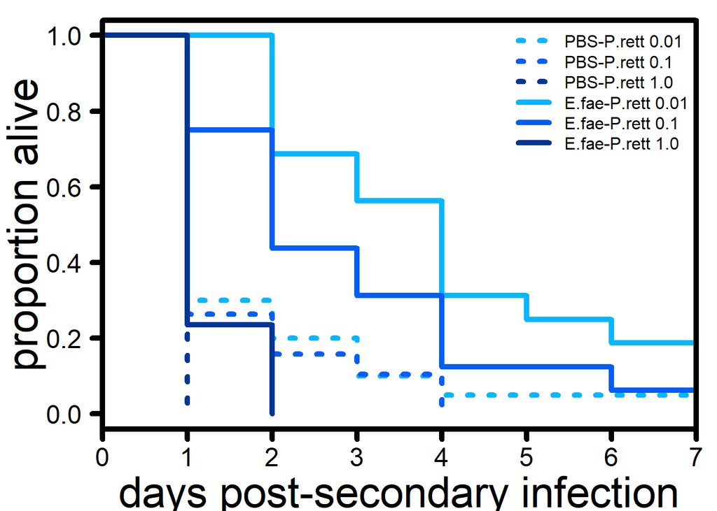

```r
E.fae_P.rett_block1 <- subset(E.fae_P.rett, Date == "6/11/2019")
par(mar=c(4,5,1,1))
plot(survfit(Surv(E.fae_P.rett_block1$day, E.fae_P.rett_block1$status) ~ E.fae_P.rett_block1$primary + E.fae_P.rett_block1$secondary_dose), col=c("#09B6FC", "#055df5", "#003694"), lty=c(3, 3, 3, 1, 1, 1), lwd=5,yaxt='n', xaxt='n', ylab="proportion alive", xlab="days post-secondary infection", cex.lab=2.5, xlim=c(0,7), xaxs='i')
axis(2, las=2, cex.axis=1.5, lwd=5)
axis(1, cex.axis=1.5, lwd=5)
box(lwd=5)
legend("topright",inset=0, bty="n" , c("PBS-P.rett 0.01", "PBS-P.rett 0.1", 'PBS-P.rett 1.0', "E.fae-P.rett 0.01", "E.fae-P.rett 0.1", "E.fae-P.rett 1.0"),col=c("#09B6FC", "#055df5", "#003694"),lty=c(3, 3, 3, 1, 1, 1),lwd=5, cex=1)
```

### Block 2

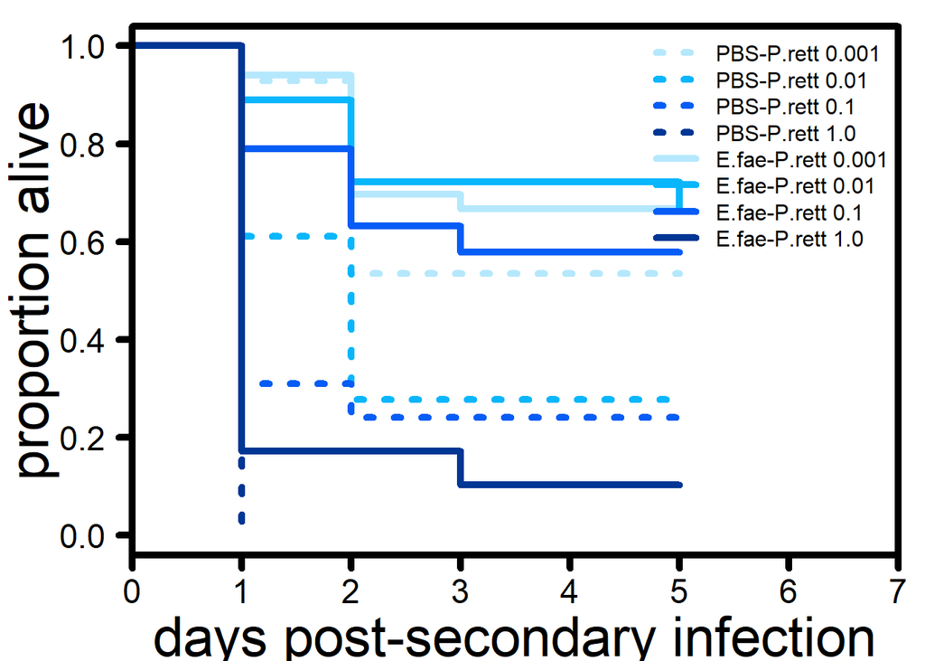

```r
E.fae_P.rett_block2 <- subset(E.fae_P.rett, Date == "6/22/2018")
par(mar=c(4,5,1,1))
plot(survfit(Surv(E.fae_P.rett_block2$day, E.fae_P.rett_block2$status) ~ E.fae_P.rett_block2$primary + E.fae_P.rett_block2$secondary_dose), col=c("#B5E8FC",  "#09B6FC", "#055df5", "#003694"), lty=c(3, 3, 3, 3, 1, 1, 1, 1), lwd=5,yaxt='n', xaxt='n', ylab="proportion alive", xlab="days post-secondary infection", cex.lab=2.5, xlim=c(0,7), xaxs='i')
axis(2, las=2, cex.axis=1.5, lwd=5)
axis(1, cex.axis=1.5, lwd=5)
box(lwd=5)
legend("topright",inset=0, bty="n" , c("PBS-P.rett 0.001", "PBS-P.rett 0.01", "PBS-P.rett 0.1", 'PBS-P.rett 1.0', "E.fae-P.rett 0.001", "E.fae-P.rett 0.01", "E.fae-P.rett 0.1", "E.fae-P.rett 1.0"),col=c("#B5E8FC", "#09B6FC", "#055df5", "#003694"),lty=c(3, 3, 3, 3, 1, 1, 1, 1),lwd=5, cex=1)
```

### Block 3

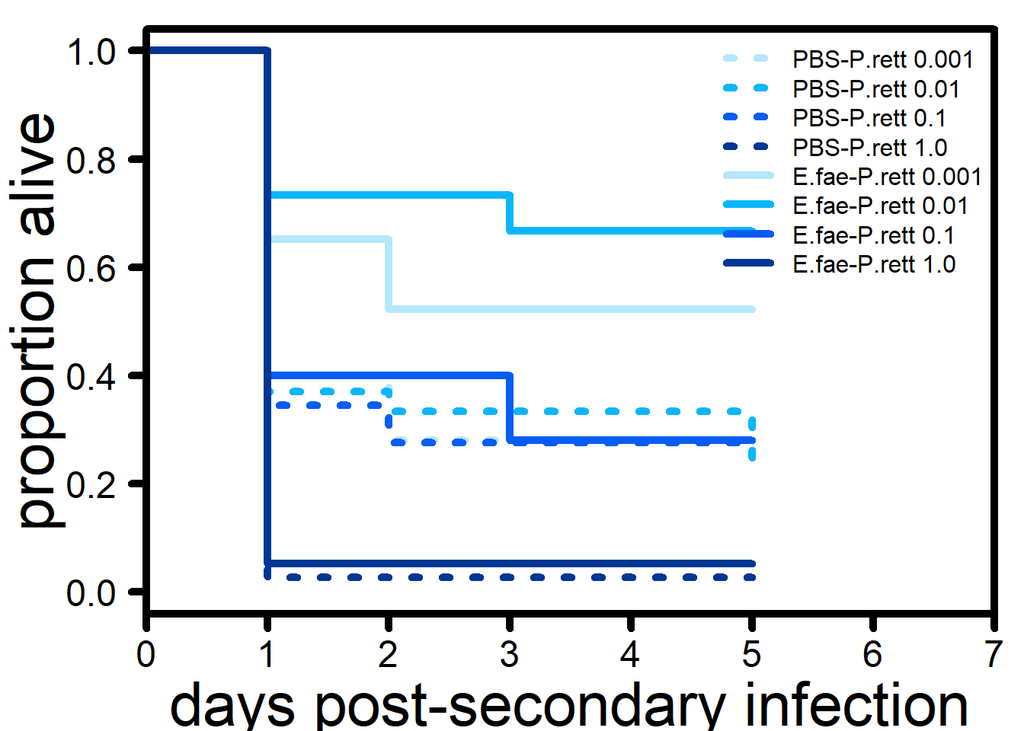

```r
E.fae_P.rett_block3 <- subset(E.fae_P.rett, Date == "6/25/2018")
par(mar=c(4,5,1,1))
plot(survfit(Surv(E.fae_P.rett_block3$day, E.fae_P.rett_block3$status) ~ E.fae_P.rett_block3$primary + E.fae_P.rett_block3$secondary_dose), col=c("#B5E8FC",  "#09B6FC", "#055df5", "#003694"), lty=c(3, 3, 3, 3, 1, 1, 1, 1), lwd=5,yaxt='n', xaxt='n', ylab="proportion alive", xlab="days post-secondary infection", cex.lab=2.5, xlim=c(0,7), xaxs='i')
axis(2, las=2, cex.axis=1.5, lwd=5)
axis(1, cex.axis=1.5, lwd=5)
box(lwd=5)
legend("topright",inset=0, bty="n" , c("PBS-P.rett 0.001", "PBS-P.rett 0.01", "PBS-P.rett 0.1", 'PBS-P.rett 1.0', "E.fae-P.rett 0.001", "E.fae-P.rett 0.01", "E.fae-P.rett 0.1", "E.fae-P.rett 1.0"),col=c("#B5E8FC", "#09B6FC", "#055df5", "#003694"),lty=c(3, 3, 3, 3, 1, 1, 1, 1),lwd=5, cex=1)
```

### Block 4

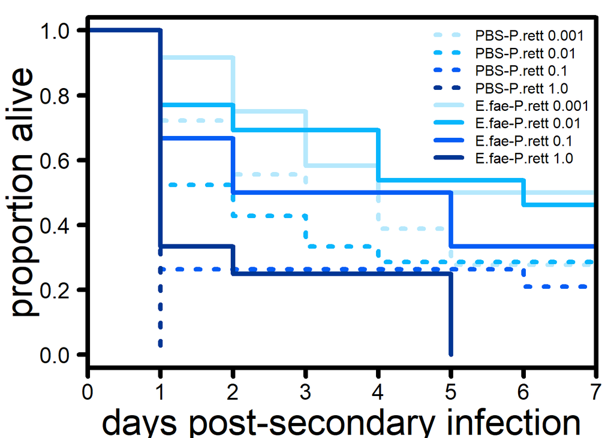

```r
E.fae_P.rett_block4 <- subset(E.fae_P.rett, Date == "6/3/2019")
par(mar=c(4,5,1,1))
plot(survfit(Surv(E.fae_P.rett_block4$day, E.fae_P.rett_block4$status) ~ E.fae_P.rett_block4$primary + E.fae_P.rett_block4$secondary_dose), col=c("#B5E8FC",  "#09B6FC", "#055df5", "#003694"), lty=c(3, 3, 3, 3, 1, 1, 1, 1), lwd=5,yaxt='n', xaxt='n', ylab="proportion alive", xlab="days post-secondary infection", cex.lab=2.5, xlim=c(0,7), xaxs='i')
axis(2, las=2, cex.axis=1.5, lwd=5)
axis(1, cex.axis=1.5, lwd=5)
box(lwd=5)
legend("topright",inset=0, bty="n" , c("PBS-P.rett 0.001", "PBS-P.rett 0.01", "PBS-P.rett 0.1", 'PBS-P.rett 1.0', "E.fae-P.rett 0.001", "E.fae-P.rett 0.01", "E.fae-P.rett 0.1", "E.fae-P.rett 1.0"),col=c("#B5E8FC", "#09B6FC", "#055df5", "#003694"),lty=c(3, 3, 3, 3, 1, 1, 1, 1),lwd=5, cex=1)
```

### Block 5

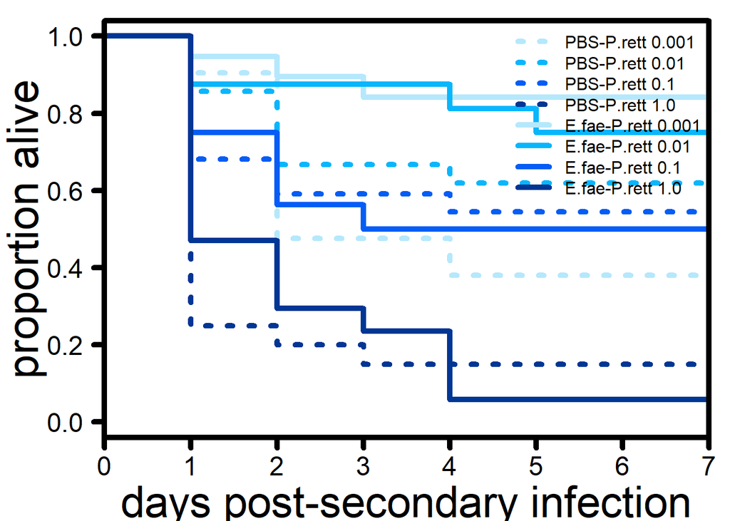

```r
E.fae_P.rett_block5 <- subset(E.fae_P.rett, Date == "6/5/2019")
par(mar=c(4,5,1,1))
plot(survfit(Surv(E.fae_P.rett_block5$day, E.fae_P.rett_block5$status) ~ E.fae_P.rett_block5$primary + E.fae_P.rett_block5$secondary_dose), col=c("#B5E8FC",  "#09B6FC", "#055df5", "#003694"), lty=c(3, 3, 3, 3, 1, 1, 1, 1), lwd=5,yaxt='n', xaxt='n', ylab="proportion alive", xlab="days post-secondary infection", cex.lab=2.5, xlim=c(0,7), xaxs='i')
axis(2, las=2, cex.axis=1.5, lwd=5)
axis(1, cex.axis=1.5, lwd=5)
box(lwd=5)
legend("topright",inset=0, bty="n" , c("PBS-P.rett 0.001", "PBS-P.rett 0.01", "PBS-P.rett 0.1", 'PBS-P.rett 1.0', "E.fae-P.rett 0.001", "E.fae-P.rett 0.01", "E.fae-P.rett 0.1", "E.fae-P.rett 1.0"),col=c("#B5E8FC", "#09B6FC", "#055df5", "#003694"),lty=c(3, 3, 3, 3, 1, 1, 1, 1),lwd=5, cex=1)
```

### Block 6

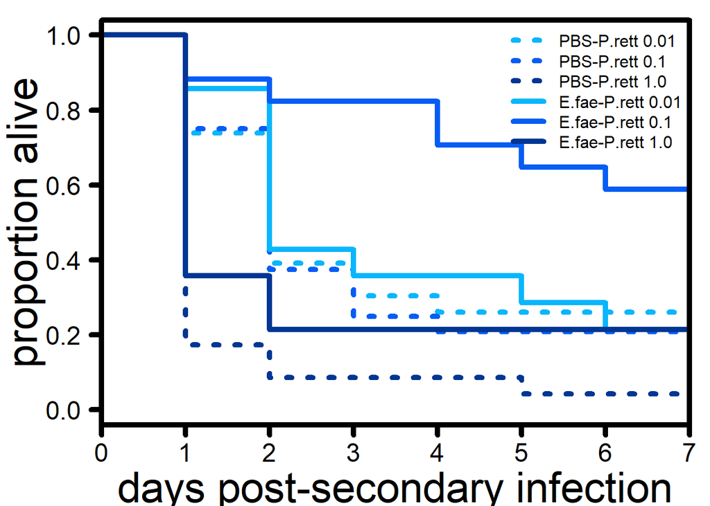

```r
E.fae_P.rett_block6 <- subset(E.fae_P.rett, Date == "7/1/2019")
par(mar=c(4,5,1,1))
plot(survfit(Surv(E.fae_P.rett_block6$day, E.fae_P.rett_block6$status) ~ E.fae_P.rett_block6$primary + E.fae_P.rett_block6$secondary_dose), col=c("#09B6FC", "#055df5", "#003694"), lty=c(3, 3, 3, 1, 1, 1), lwd=5,yaxt='n', xaxt='n', ylab="proportion alive", xlab="days post-secondary infection", cex.lab=2.5, xlim=c(0,7), xaxs='i')
axis(2, las=2, cex.axis=1.5, lwd=5)
axis(1, cex.axis=1.5, lwd=5)
box(lwd=5)
legend("topright",inset=0, bty="n" , c("PBS-P.rett 0.01", "PBS-P.rett 0.1", 'PBS-P.rett 1.0', "E.fae-P.rett 0.01", "E.fae-P.rett 0.1", "E.fae-P.rett 1.0"),col=c("#09B6FC", "#055df5", "#003694"),lty=c(3, 3, 3,  1, 1, 1),lwd=5, cex=1)
```

### Block 7

Not sure why the data stops after 3 days, Frank did this one

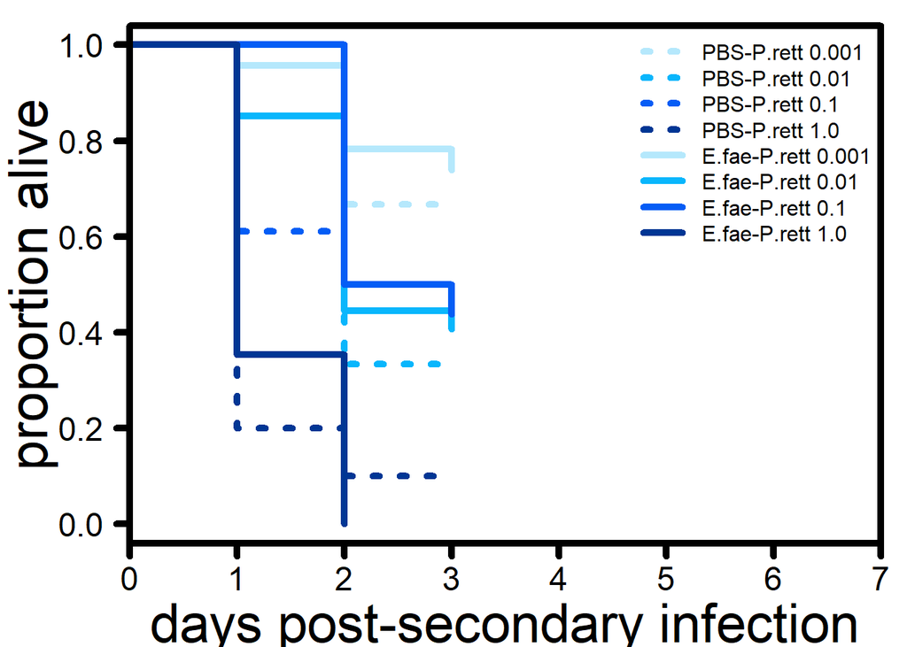

```r
E.fae_P.rett_block7 <- subset(E.fae_P.rett, Date == "7/19/2018")
par(mar=c(4,5,1,1))
plot(survfit(Surv(E.fae_P.rett_block7$day, E.fae_P.rett_block7$status) ~ E.fae_P.rett_block7$primary + E.fae_P.rett_block7$secondary_dose), col=c("#B5E8FC",  "#09B6FC", "#055df5", "#003694"), lty=c(3, 3, 3, 3, 1, 1, 1, 1), lwd=5,yaxt='n', xaxt='n', ylab="proportion alive", xlab="days post-secondary infection", cex.lab=2.5, xlim=c(0,7), xaxs='i')
axis(2, las=2, cex.axis=1.5, lwd=5)
axis(1, cex.axis=1.5, lwd=5)
box(lwd=5)

legend("topright",inset=0, bty="n" , c("PBS-P.rett 0.001", "PBS-P.rett 0.01", "PBS-P.rett 0.1", 'PBS-P.rett 1.0', "E.fae-P.rett 0.001", "E.fae-P.rett 0.01", "E.fae-P.rett 0.1", "E.fae-P.rett 1.0"),col=c("#B5E8FC", "#09B6FC", "#055df5", "#003694"),lty=c(3, 3, 3, 3, 1, 1, 1, 1),lwd=5, cex=1)
```

### Block 8

something seems very wrong with this there are only 7 flies for chronically infected with the highest dose and 9 for the second highest I did this one but need to check my binder to see why I did it like this

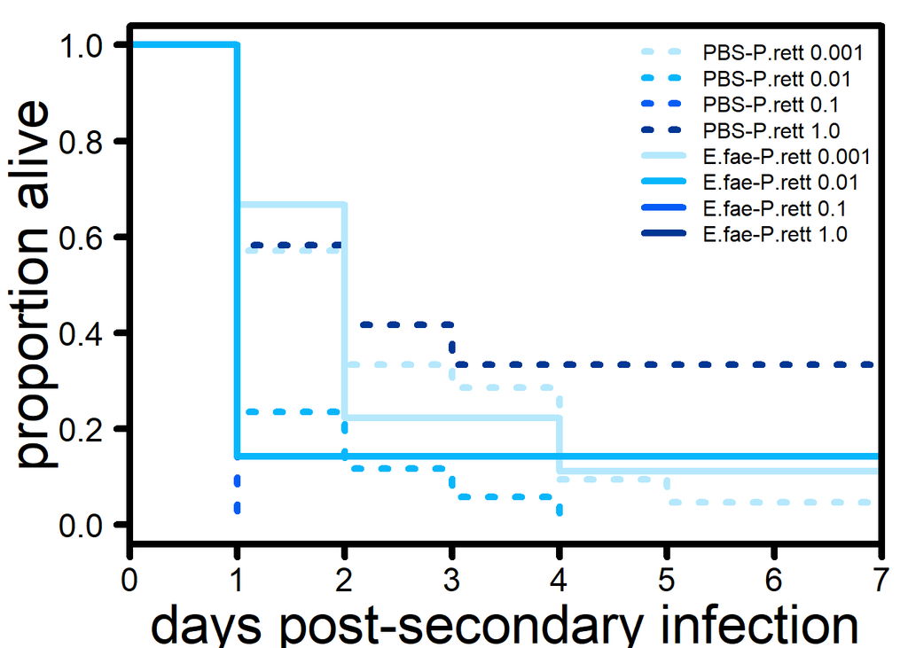

```r
E.fae_P.rett_block8 <- subset(E.fae_P.rett, Date == "7/3/2019")
par(mar=c(4,5,1,1))
plot(survfit(Surv(E.fae_P.rett_block8$day, E.fae_P.rett_block8$status) ~ E.fae_P.rett_block8$primary + E.fae_P.rett_block8$secondary_dose), col=c("#B5E8FC",  "#09B6FC", "#055df5", "#003694"), lty=c(3, 3, 3, 3, 1, 1, 1, 1), lwd=5,yaxt='n', xaxt='n', ylab="proportion alive", xlab="days post-secondary infection", cex.lab=2.5, xlim=c(0,7), xaxs='i')
axis(2, las=2, cex.axis=1.5, lwd=5)
axis(1, cex.axis=1.5, lwd=5)
box(lwd=5)
legend("topright",inset=0, bty="n" , c("PBS-P.rett 0.001", "PBS-P.rett 0.01", "PBS-P.rett 0.1", 'PBS-P.rett 1.0', "E.fae-P.rett 0.001", "E.fae-P.rett 0.01", "E.fae-P.rett 0.1", "E.fae-P.rett 1.0"),col=c("#B5E8FC", "#09B6FC", "#055df5", "#003694"),lty=c(3, 3, 3, 3, 1, 1, 1, 1),lwd=5, cex=1)
```